# Time Series: A First Course with Bootstrap Starter

# Lesson 18: Sample Autocovariance

We want to estimate the ACVF: they are used in prediction, and are helpful in understanding serial dependence in the time series.

## Remark 9.4.1. ACVF Estimator for Known Mean

- Suppose that the mean $\mu$ of the stationary time series $\{ X_t \}$ was known, and we want to estimate $\gamma (h)$.
- This is the expectation of $Y_t$, where
  $$Y_t = (X_{t+h} - \mu)(X_t - \mu).$$
- We can compute $Y_1,\ldots, Y_{n-h}$ for any $0 \leq h < n$, because $\mu$ is known.
- The sample mean of these would be
  $$\frac{1}{n-h} \sum_{t=1}^{n-h} Y_t =
  \frac{1}{n-h} \sum_{t=1}^{n-h} (X_{t+h} - \mu)(X_t - \mu).$$
  This has expectation $\gamma (h)$.
- The long-run variance of this sample mean is based on the ACVF of $\{ Y_t \}$, and has a complicated expression known as *Bartlett’s Formula*.
- This suggests an estimator
  $$\overline{\gamma} (h) = \frac{1}{n-h} \sum_{t=1}^{n-h} (X_{t+h} - \mu)(X_t - \mu),$$
  which is unbiased for $\gamma (h)$.

## Proposition 9.4.3. Bartlett’s Formula

Suppose $\{ X_t \}$ is a causal linear time series with i.i.d. inputs $\{ Z_t \}$, which have variance $\sigma^2$ and kurtosis $\eta$. Then the long-run variance of $\overline{\gamma}(h)$ is
$$\tau^2_{\infty} = \sum_{k = -\infty}^{\infty} \left( \gamma (k+h) \gamma (k-h) + { \gamma (k)}^2 \right)
+ { \gamma (h)}^2 (\eta - 3).$$

## Remark 9.4.6. ACVF Estimator for Unknown Mean

- Since $\mu$ is usually unknown, we can replace it by the sample mean $\overline{X}$.
- The resulting estimator is asymptotically normal when the process $\{ X_t \}$ is $m$-dependent (i.e., random variables of at least lag $m$ between them are independent).

## Remark 9.5.5. The Sample ACVF

- The so-called *sample autocovariance function* (sample ACVF) is obtained by replacing $\mu$ by $\overline{X}$ in $\overline{\gamma} (h)$, and rescaling to guarantee a positive definite sequence:
  $$\widehat{\gamma} (h) = \frac{1}{n} \sum_{t=1}^{n-h} (X_{t+h} - \overline{X})
  (X_t - \overline{X})$$
  for $h \geq 0$.
- Under $m$-dependence, Corollary 9.5.8 establishes a central limit theorem for the sample ACVF:
  $$\sqrt{n} ( \widehat{\gamma} (h) - \gamma (h)) \Rightarrow \mathcal{N} (0, \tau^2_{\infty}).$$

## Exercise 9.28. Sample ACVF of ARMA(1,2) Process

- We simulate a Gaussian ARMA(1,2) process of length $n=200$.

```r
armapq.sim <- function(n,burn,ar.coefs,ma.coefs,innovar)
{
    p <- length(ar.coefs)
    q <- length(ma.coefs)
    z <- rnorm(n+burn+p+q,sd=sqrt(innovar))
    x <- filter(z,c(1,ma.coefs),method="convolution",sides=1)
    x <- x[(q+1):(q+n+burn+p)]
    y <- x[1:p]
    for(t in (p+1):(p+n+burn))
    {
        next.y <- sum(ar.coefs*y[(t-1):(t-p)]) + x[t]
        y <- c(y,next.y)
    }
    y <- y[(p+burn+1):(p+burn+n)]
    return(y)
}

n <- 200
phi1 <- .5
theta1 <- 5/6
theta2 <- 1/6
x.sim <- armapq.sim(n,500,phi1,c(theta1,theta2),1)
```

- We construct and plot the sample acvf.

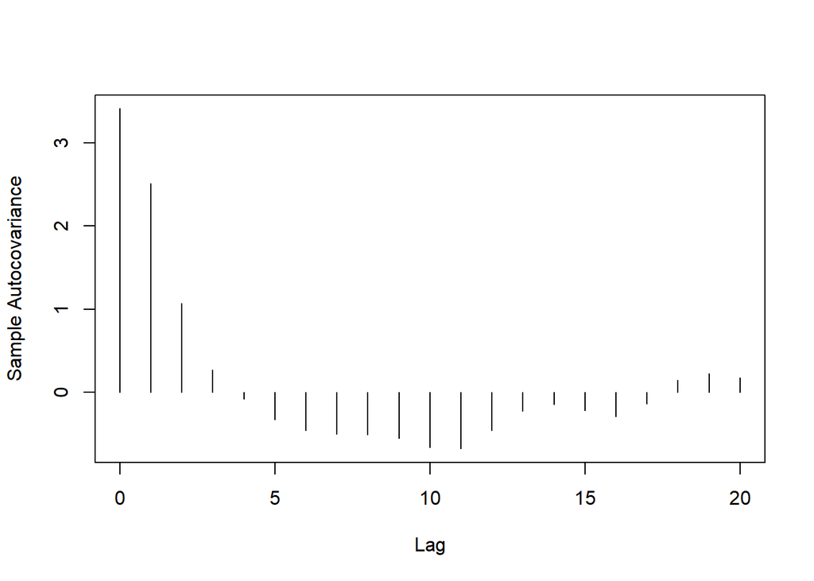

```r
y.sim <- x.sim - mean(x.sim)
x.acf <- mean(y.sim^2)
for(h in 1:20)
{
    x.acf <- c(x.acf,sum(y.sim[1:(n-h)]*y.sim[(h+1):n])/n)
}
plot(ts(x.acf,start=0,frequency=1),xlab="Lag",ylab="Sample Autocovariance",type="h")
```